# Data Science

## Data Science

## Data Modeling

Data modeling goal:

- describe a dataset using a relatively small number of mathematical relationships, or
- use some parts of a dataset to try to accurately predict other parts of the dataset

## Models are human inventions

Models:

- reflect our beliefs about the way the universe works
- can identify patterns within a dataset that are the result of causal relationships
- separate meaningful signal of interest from noise
- *the model itself does not identify or even accurately reflect those causal effects*
- summarizes patterns and we as scientists are left to interpret those patterns

## Data Modeling Principles

1. **Data are never wrong.**
2. **Not all data are useful.**
3. **“All models are wrong, but some are useful.”** - George Box
4. **Data do not contain causal information.**
   - i.e. “Correlation does not mean causation.”
5. **All data have noise.**

## Types of Models

- **Scientific model**:
  - conceptual representation of our belief of the universe
  - proposes causal explanations for phenomenon, i.e. *hypotheses*
  - helps us design experiments and collect data to test the accuracy of the model
- **Statistical model**:
  - maps a scientific model onto a mechanical procedure
  - quantifies how well our scientific model explains a dataset

*The scientific model and statistical model are related but independent choices we make*

## Data Exploration

- We might lack sufficient information to form a scientific model
- Must first gain knowledge by examining data
- Can then possibly generate a scientific model
- This step sometimes called *exploratory data analysis* (EDA)

## A Worked Modeling Example

Consider three imaginary genes measured in Parkinson’s Disease (PD) patients blood:

```r
set.seed(1337)
gene_exp <- tibble(
  sample_name = c(str_c("P",1:100), str_c("C",1:100)),
  `Disease Status` = factor(c(rep("PD",100),rep("Control",100))),
  `Gene 1` = c(rnorm(100,255,10), rnorm(100,250,10)),
  `Gene 2` = c(rnorm(100,520,100), rnorm(100,600,60)),
  `Gene 3` = c(rnorm(100,500,40), rnorm(100,330,40))
)
```

## A Worked Modeling Example

```r
gene_exp
```

```
## # A tibble: 200 × 5
##    sample_name `Disease Status` `Gene 1` `Gene 2` `Gene 3`
##    <chr>       <fct>               <dbl>    <dbl>    <dbl>
##  1 P1          PD                   257.     636.     504.
##  2 P2          PD                   241.     556.     484.
##  3 P3          PD                   252.     426.     476.
##  4 P4          PD                   271.     405.     458.
##  5 P5          PD                   248.     482.     520.
##  6 P6          PD                   275.     521.     460.
##  7 P7          PD                   264.     415.     568.
##  8 P8          PD                   276.     450.     495.
##  9 P9          PD                   274.     490.     496.
## 10 P10         PD                   251.     584.     573.
## # ℹ 190 more rows
```

## Data Exploration

```r
pivot_longer(
  gene_exp,
  c(`Gene 1`, `Gene 2`, `Gene 3`),
  names_to="Gene",
  values_to="Expression"
) %>% ggplot(
    aes(x=`Disease Status`,y=Expression,fill=`Disease Status`)
  ) +
  facet_wrap(vars(Gene)) +
  geom_violin()
```

## Data Exploration

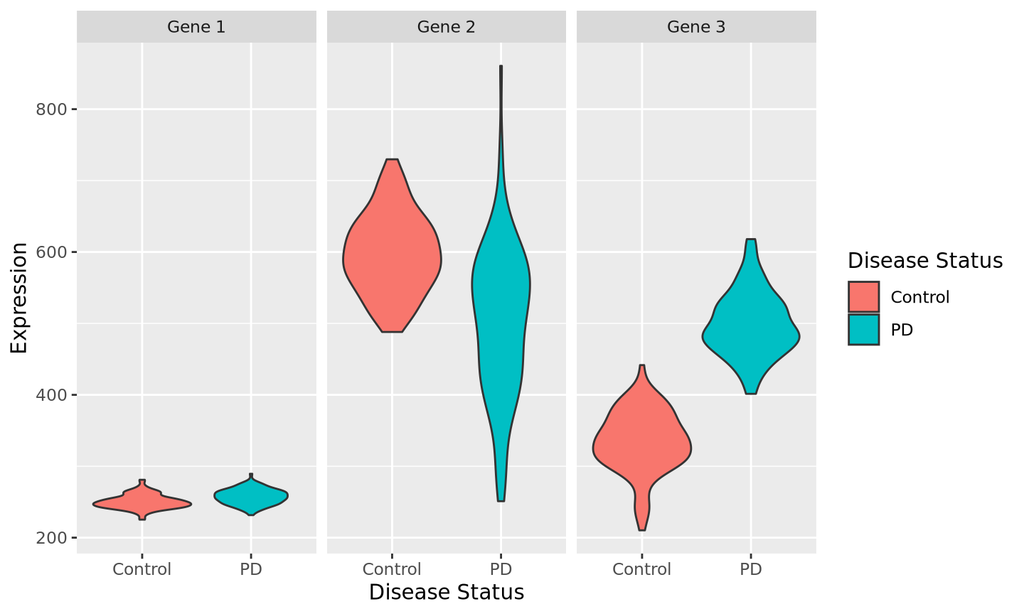

## Observations

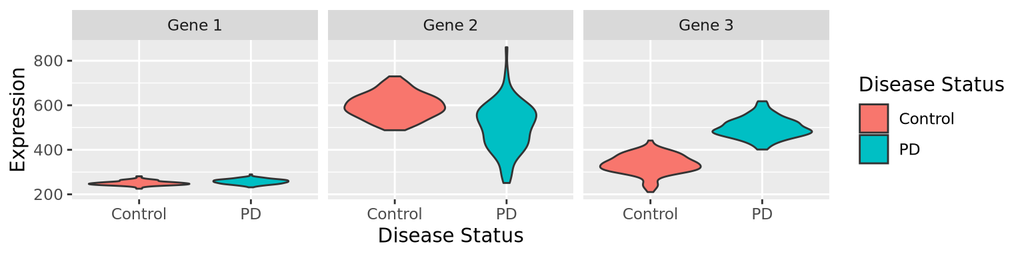

- Gene 1 does not look different between PD and control
- Gene 2 looks to have different means, but distributions overlap
- Gene 3 is very different in PD versus control
- Qualitative observations: *We made them with our eyes*
- How do we quantify these observations?

## Questions We Might Ask

- How much higher is Gene 3 expression in PD than control?
- If I know/suspect a patient has PD, what Gene 3 expression might we expect them to have?
- If all I know about a patient is their gene expression, how likely is it that they have PD?

## Data Summarization

## Data Summarization

- *data summarization* - process of finding a lower-dimensional representation of larger dataset
- A histogram is a summarization:

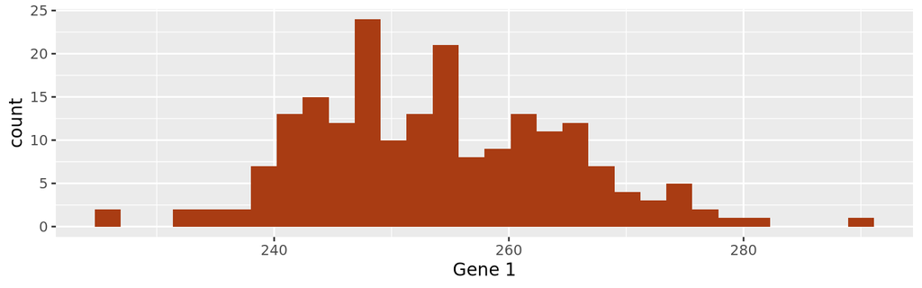

```r
ggplot(gene_exp, aes(x=`Gene 1`)) +
  geom_histogram(bins=30,fill="#a93c13")
```

## Point Estimates

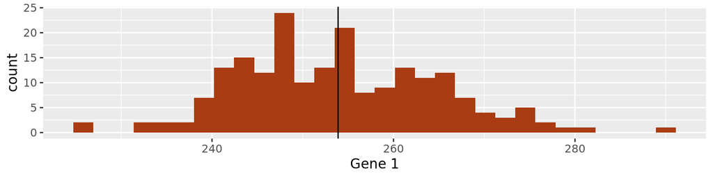

```r
ggplot(gene_exp, aes(x=`Gene 1`)) +
  geom_histogram(bins=30,fill="#a93c13") +
  geom_vline(xintercept=mean(gene_exp$`Gene 1`))
```

## Poor Point Estimates

```r
library(patchwork)
well_behaved_data <- tibble(data = rnorm(1000))
# introduce some outliers
data_w_outliers <- tibble(data = c(rnorm(800), rep(5, 200)))

g_no_outlier <- ggplot(well_behaved_data, aes(x = data)) +
  geom_histogram(fill = "#56CBF9", color = "grey", bins = 30) +
  geom_vline(xintercept = mean(well_behaved_data$data)) +
  ggtitle("Mean example, no outliers")

g_outlier <- ggplot(data_w_outliers, aes(x = data)) +
  geom_histogram(fill = "#7FBEEB", color = "grey", bins = 30) +
  geom_vline(xintercept = mean(data_w_outliers$data)) +
  ggtitle("Mean example, big outliers")

g_no_outlier | g_outlier
```

## Poor Point Estimates

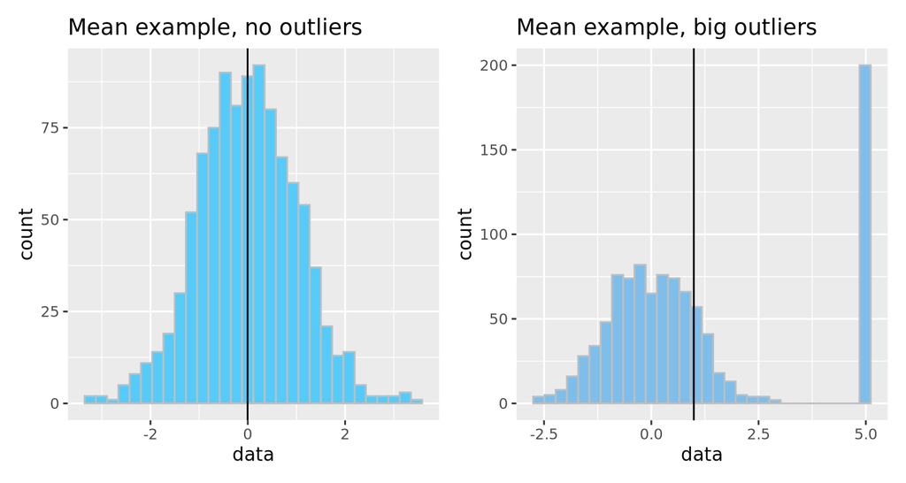

## Other Point Estimates

```r
g_no_outlier <- ggplot(well_behaved_data, aes(x = data)) +
  geom_histogram(fill = "#AFBED1", color = "grey", bins = 30) +
  geom_vline(xintercept = median(well_behaved_data$data)) +
  ggtitle("Median example")

g_outlier <- ggplot(data_w_outliers, aes(x = data)) +
  geom_histogram(fill = "#7FBEEB", color = "grey", bins = 30) +
  geom_vline(xintercept = median(data_w_outliers$data)) +
  ggtitle("Median example, big outliers")

g_no_outlier | g_outlier
```

## Other Point Estimates

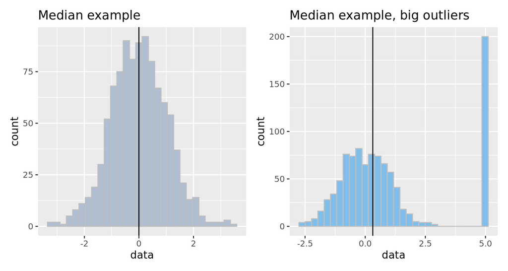

## Dispersion

- *Dispersion* describes the “spread” of the data
- e.g. standard deviation `sd()`

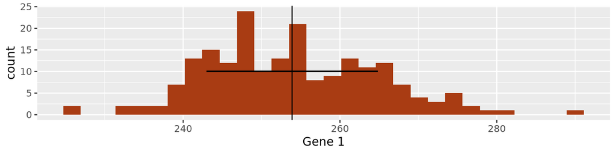

```r
g1_mean <- mean(gene_exp$`Gene 1`)
g1_sd <- sd(gene_exp$`Gene 1`)
ggplot(gene_exp, aes(x=`Gene 1`)) +
  geom_histogram(bins=30,fill="#a93c13") +
  geom_vline(xintercept=g1_mean) +
  geom_segment(x=g1_mean-g1_sd, y=10, xend=g1_mean+g1_sd, yend=10)
```

## Standard deviation

- measure how close values are to the mean

```r
data <- tibble(data = c(rnorm(1000, sd=1.75)))
ggplot(data, aes(x = data)) +
  geom_histogram(fill = "#EAC5D8", color = "white", bins = 30) +
  geom_vline(xintercept = seq(-3,3,1) * sd(data$data)) +
  xlim(c(-6, 6)) +
  ggtitle("Standard deviations aplenty", paste("SD:", sd(data$data)))
```

## Standard deviation

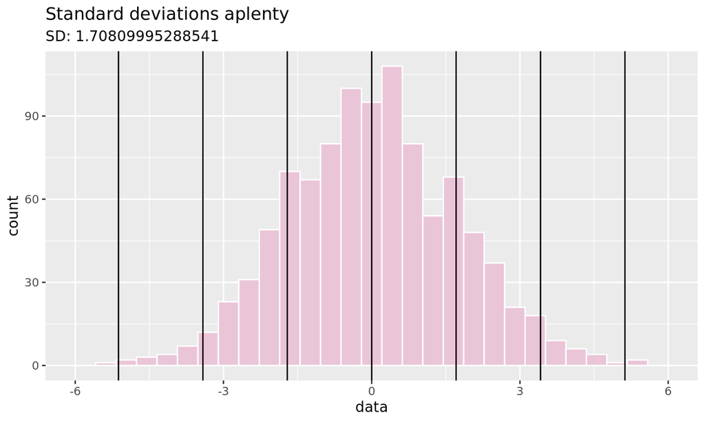

## Normal Distribution

- *Central tendency* and *dispersion* estimates describe a *normal distribution*
- Can visually inspect fit of a distribution to data:

```r
g1_mean <- mean(gene_exp$`Gene 1`)
g1_sd <- sd(gene_exp$`Gene 1`)
ggplot(gene_exp, aes(x=`Gene 1`)) +
  geom_histogram(
    aes(y=after_stat(density)),
    bins=30,
    fill="#a93c13"
  ) +
  stat_function(fun=dnorm,
    args = list(mean=g1_mean, sd=g1_sd),
    linewidth=2
  )
```

## Normal Distribution

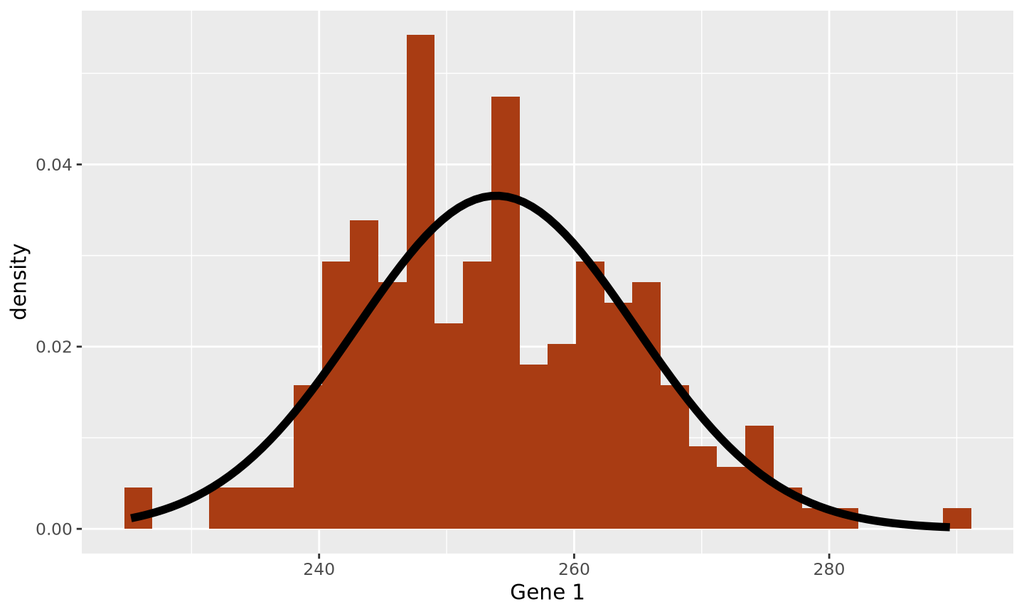

## Our First Model

- We chose to express the dataset as a normal distribution parameterized by:
  - arithmetic mean - 254
  - standard deviation - 11

\[ Gene\;1 \sim \mathcal{N}(254, 11) \]

## Other distributions

```r
g_norm <- ggplot(tibble(data = rnorm(5000)), aes(x = data)) +
  geom_histogram(fill = "#D0FCB3", bins = 50, color = "gray") +
  ggtitle("Normal distribution", "rnorm(n = 1000)")

g_unif <- ggplot(tibble(data = runif(5000)), aes(x = data)) +
  geom_histogram(fill = "#271F30", bins = 50, color = "white") +
  ggtitle("Uniform distribution", "runif(n = 1000)")

g_logistic <- ggplot(tibble(data = rlogis(5000)), aes(x = data)) +
  geom_histogram(fill = "#9BC59D", bins = 50, color = "black") +
  ggtitle("Logistic distribution", "rlogis(n = 1000)")

g_exp <- ggplot(tibble(data = rexp(5000, rate = 1)), aes(x = data)) +
  geom_histogram(fill = "#6C5A49", bins = 50, color = "white") +
  ggtitle("Exponential distribution", "rexp(n = 1000, rate = 1)")

(g_norm | g_unif) / (g_logistic | g_exp)
```

## Other distributions

[figure not shown]

## Some notes on our model

We chose to model our gene 1 expression data using a normaly distribution parameterized by the arithmetic mean and standard deviation

1. **Our model choice was totally subjective**
2. **We can’t know if this is the “correct” model for the data**
3. **We don’t know how well our model describes the data yet**

## Linear Models

## Linear Models

- Data distributions are *descriptive*
- They may not be *informative*
- Recall one of our scientific questions:
  - If all I know about a patient is their gene expression, how likely is it that they have PD?
- Our model doesn’t answer this question yet

## The Linear Model

- *linear model*: any statistical model that relates one outcome variable as a linear combination (i.e. sum) of one or more explanatory variables
- For the mathematically inclined:

\[ Y_i = \beta_0 + \beta_1 \phi_1 ( X_{i1} ) + \beta_2 \phi_2 ( X_{i2} ) + \ldots + \beta_p \phi_p ( X_{ip} ) + \epsilon_i \]

## Back To Working Example

- beeswarm plot plot of Gene 3:

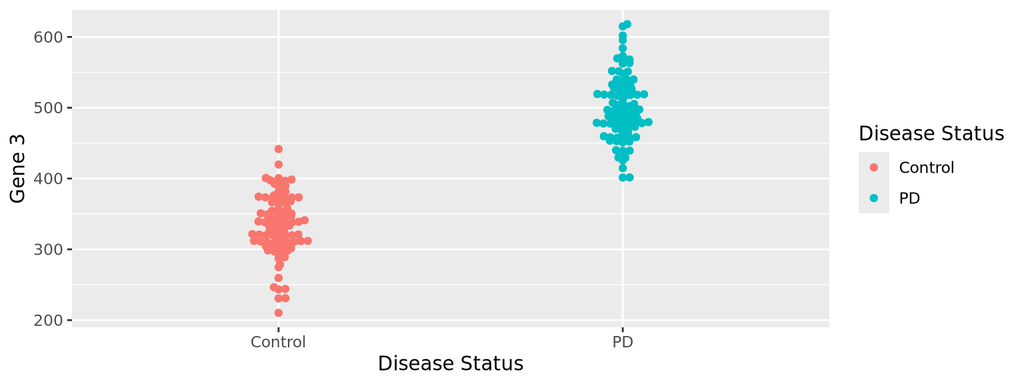

```r
library(ggbeeswarm)
ggplot(gene_exp, aes(x=`Disease Status`, y=`Gene 3`, color=`Disease Status`)) +
  geom_beeswarm()
```

## Plot Same Data Differently

```r
exp_summ <- pivot_longer( gene_exp, c(`Gene 3`)
  ) %>%
  group_by(`Disease Status`) %>%
  summarize(mean=mean(value),sd=sd(value))

pd_mean <- filter(exp_summ, `Disease Status` == "PD")$mean
c_mean <- filter(exp_summ, `Disease Status` == "Control")$mean

ggplot(gene_exp, aes(x=`Gene 3`, fill=`Disease Status`)) +
  geom_histogram(bins=20, alpha=0.6,position="identity") +
  annotate("segment", x=c_mean, xend=pd_mean, y=20, yend=20,
    arrow=arrow(ends="both", angle=90)) +
  annotate("text", x=mean(c(c_mean,pd_mean)), y=21, hjust=0.5,
    label="How different?")
```

## Plot Same Data Differently

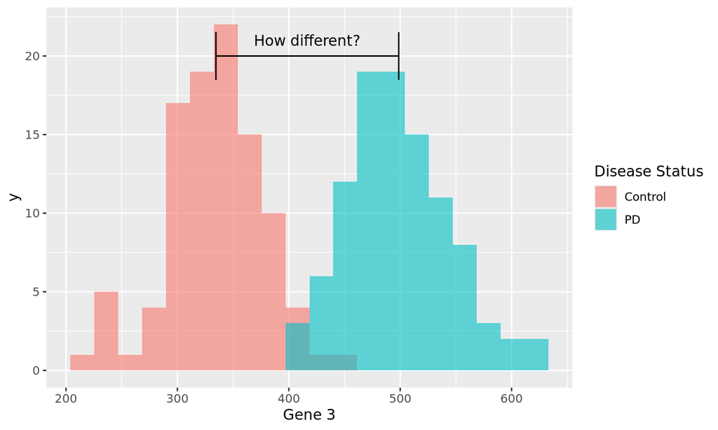

## Estimate Difference

- make a point estimate of this difference by simply subtracting the means:

```r
pd_mean - c_mean
```

```
## [1] 164.0942
```

In other words, this point estimate suggests that on average Parkinson’s patients have 164.1 greater expression than Controls.

## Visualizing this Difference

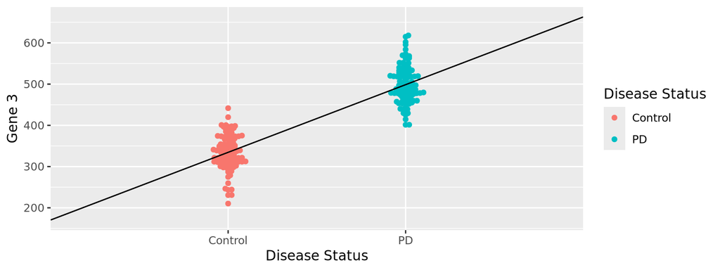

```r
ggplot(gene_exp, aes(x=`Disease Status`, y=`Gene 3`,
                     color=`Disease Status`)) +
  geom_beeswarm() +
  annotate("segment", x=0, xend=3,
           y=2*c_mean-pd_mean, yend=2*pd_mean-c_mean)
```

## Linear Model Terminology

- Our difference is an *estimate*, but how good is it?
- Linear models estimate both the difference *and* our confidence in that estimate
- Mathematically:
  - \[Gene 3 = \beta_0 + \beta_1*Disease Status\]
- \(\beta_0\) and \(\beta_1\) are called *coefficients*
  - \(\beta_0\) is our intercept term
  - \(\beta_1\) is our point estimate of difference between PD and Control
- Computing these coefficients is called *fitting the model*
- This style of analysis is called *linear regression*

## Linear Models in R

- In R, specify formula like `Y ~ X`, or `Gene 3 ~ Disease Status`

```r
fit <- lm(`Gene 3` ~ `Disease Status`, data=gene_exp)
fit
```

```
##
## Call:
## lm(formula = `Gene 3` ~ `Disease Status`, data = gene_exp)
##
## Coefficients:
##        (Intercept)  `Disease Status`PD
##              334.6               164.1
```

## `lm()` Fit

```r
summary(fit)
```

```
##
## Call:
## lm(formula = `Gene 3` ~ `Disease Status`, data = gene_exp)
##
## Residuals:
##      Min       1Q   Median       3Q      Max
## -124.303  -25.758   -2.434   30.518  119.348
##
## Coefficients:
##                    Estimate Std. Error t value Pr(>|t|)
## (Intercept)         334.578      4.414   75.80   <2e-16 ***
## `Disease Status`PD  164.094      6.243   26.29   <2e-16 ***
## ---
## Signif. codes:  0 '***' 0.001 '**' 0.01 '*' 0.05 '.' 0.1 ' ' 1
##
## Residual standard error: 44.14 on 198 degrees of freedom
## Multiple R-squared:  0.7773, Adjusted R-squared:  0.7761
## F-statistic:   691 on 1 and 198 DF,  p-value: < 2.2e-16
```

## Computing Fit: naive

```r
# naive solution
fit1 <- lm(`Gene 1` ~ `Disease Status`, data=gene_exp)
fit2 <- lm(`Gene 2` ~ `Disease Status`, data=gene_exp)
fit3 <- lm(`Gene 3` ~ `Disease Status`, data=gene_exp)
```

## Computing Fit

```r
gene_stats <- lapply(
  c("Gene 1", "Gene 2", "Gene 3"),
  function(gene) {
    model <- paste0('`',gene,'`',' ~ `Disease Status`')
    fit <- lm(model, data=gene_exp)
    v <- c(gene,
           coefficients(fit),
           summary(fit)$coefficients[2,4]
           )
    names(v) <- c("Gene", "Intercept", "PD", "pvalue")
    return(v)
  }
  ) %>%
  bind_rows() # turn the list into a tibble

# compute FDR from nominal p-values
gene_stats$padj <- p.adjust(gene_stats$pvalue,method="fdr")
```

## Computed Fit

```r
gene_stats
## A tibble: 3 × 5
#  Gene   Intercept  PD       pvalue      padj
#  <chr>  <chr>      <chr>    <chr>       <dbl>
#1 Gene 1 250.410    6.959    3.921e-06   3.92e- 6
#2 Gene 2 597.763    -93.629  2.373e-13   3.56e-13
#3 Gene 3 334.577    164.094  1.727e-66   5.18e-66
```

## Plotting fit

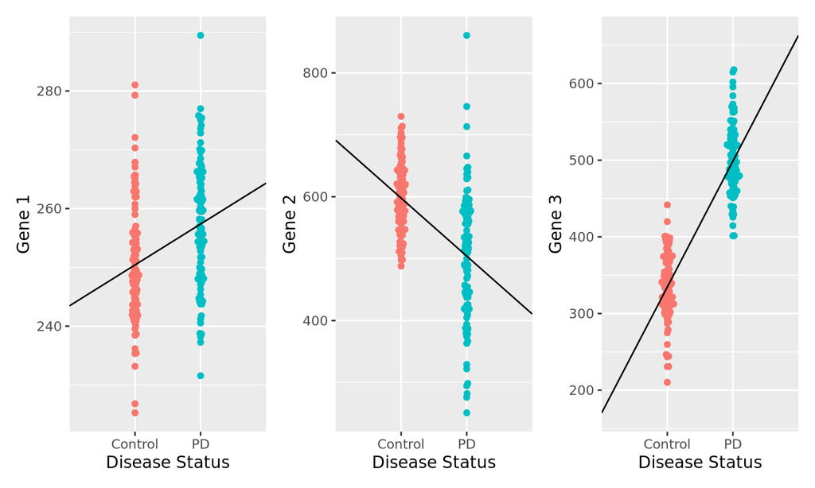

## Generalized Linear Models

- Linear regression makes strong assumptions about the distribution of the data
- [Generalized linear models](https://en.wikipedia.org/wiki/Generalized_linear_model) that allow these assumptions to be relaxed
- Mathematically, function \(g\) allows different relationships between \(X\) and \(Y\):

\[Y = g^{-1}(\beta_0 + \beta_1 \phi_1 ( X_{i1} ) + \beta_2 \phi_2 ( X_{i2} ) + \ldots + \beta_p \phi_p ( X_{ip} ))\]

## Flavors of Linear Models

- **Logistic regression**
- **Multinomial regression**
- **Poisson regression**
- **Negative binomial regression**

## Statistical Distributions

## Statistical Distributions

- Statistics was created to quantify uncertainty
- Statistics provides tools to separate *signal* from *noise*
- The *statistical distribution* is a tool we can use to estimate and quantify uncertainty

## Random Variables

- A random variable is an object or quantity which:
  - depends upon random events
  - can have samples drawn from it
- Each random variable has a potential set of possible outcomes (e.g. a real number, an integer, a category, a mathematical tree)
- Each possible outcome has some probability of appearing, relative to other outcomes
- The complete mapping of relative probabilities to outcomes for a random variable forms a *distribution*

## Random Variable Examples

- a six-sided die
- a coin
- transcription of a gene

## Random Variable Notation

- Usually notated as capital letters, like \(X,Y,Z,\) etc
- A sample drawn from a random variable is usually notated as a lowercase of the same letter
- e.g. \(x\) is a sample drawn from the random variable \(X\)
- Distribution of random variable usually described like
  - “\(X\) follows a binomial distribution”
  - “\(Y\) is a normally distributed random variable”
- Probability of a random variable taking one of its possible values: \(P(X = x)\)

## Statistical Distribution Basics

- A statistical distribution is a function that maps **the possible values for a variable to how often they occur**
- Alternatively, distribution describes the probability of seeing a single value, or a range of values, relative to all other possible values

```r
tibble(
  x = seq(-4,4,by=0.1),
  `Probability Density`=dnorm(x,0,1)
) %>%
  ggplot(aes(x=x,y=`Probability Density`)) +
  geom_line() +
  labs(title="Probability Density Function for a Normal Distribution")
```

## Normal Distribution

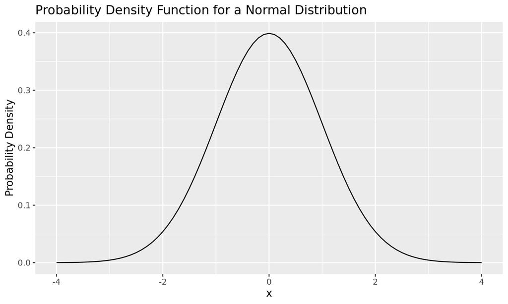

## Probability Density Functions

- *probability density function* (PDF) defines probability associated with every possible value of a random variable
- Many PDFs have a closed mathematical form
- The PDF for the normal distribution is:

\[ P(X = x|\mu,\sigma) = \frac{1}{\sigma\sqrt{2\pi}}e^{\frac{-(x-\mu)^2}{2\sigma}} \]

## PDFs

\[ P(X = x|\mu,\sigma) = \frac{1}{\sigma\sqrt{2\pi}}e^{\frac{-(x-\mu)^2}{2\sigma}} \]

- Notation \(P(X = x|\mu,\sigma)\) - “the probability that the random variable \(X\) takes the value \(x\), given mean \(\mu\) and standard deviation \(\sigma\)”
- Normal distribution is a *parametric distribution* because PDF requires two parameters
- *Non-parametric distributions* do not require parameters, but are determined from data

## Probability Mass Functions

- PDFs only defined for continuous distributions, with infinite possible values
- Discrete distributions have a finite set of possible values
- *Probability mass functions* discrete distribution analog for PDFs

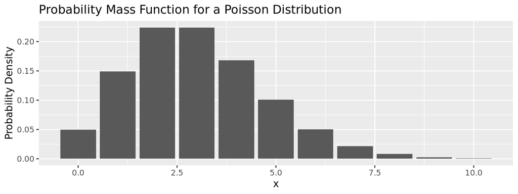

## Note: Probability of Zero

- In probability theory, if a plausible event has a probability of zero, this *does not mean that event can never occur*
- Every specific value in a continuous distribution that supports all real numbers has a probability of zero
- PDF allows us to reason about the *relative likelihood* of observing values in one range of the distribution compared with the others

## Cumulative Distribution Function

- PDF provides the probability density of specific values within the distribution
- Sometimes we want probability of a value being less/greater than or equal to a particular value
- *Cumulative distribution function* (CDF) useful for this purpose

```r
tibble(
  x = seq(-4,4,by=0.1),
  PDF=dnorm(x,0,1),
  CDF=pnorm(x,0,1)
) %>%
  ggplot() +
  geom_line(aes(x=x,y=PDF,color="PDF")) +
  geom_line(aes(x=x,y=CDF,color="CDF"),linetype="dashed")
```

## PDF vs CDF

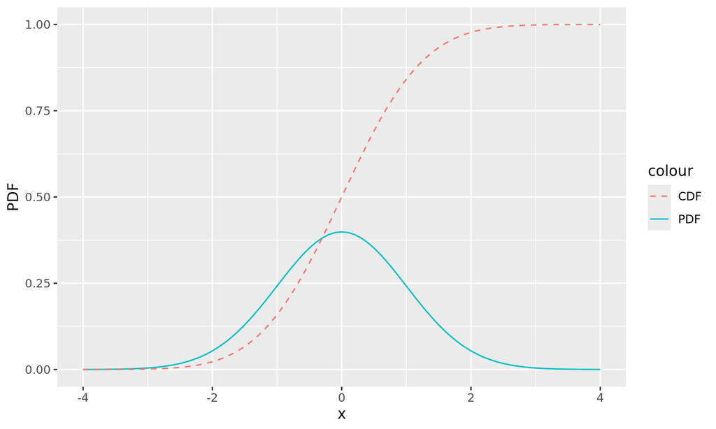

## CDF

- CDF corresponds to area under density curve up to value of \(x\)
- 1 minus that value is the area under the curve greater than that value

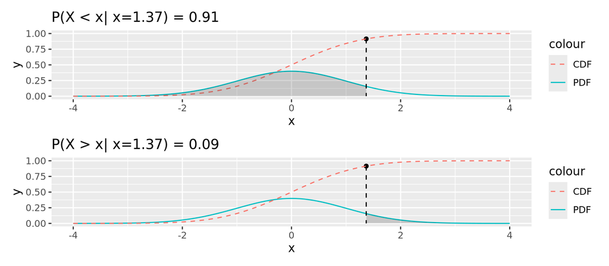

## Generating random samples

- CDF is useful for generating samples from the distribution

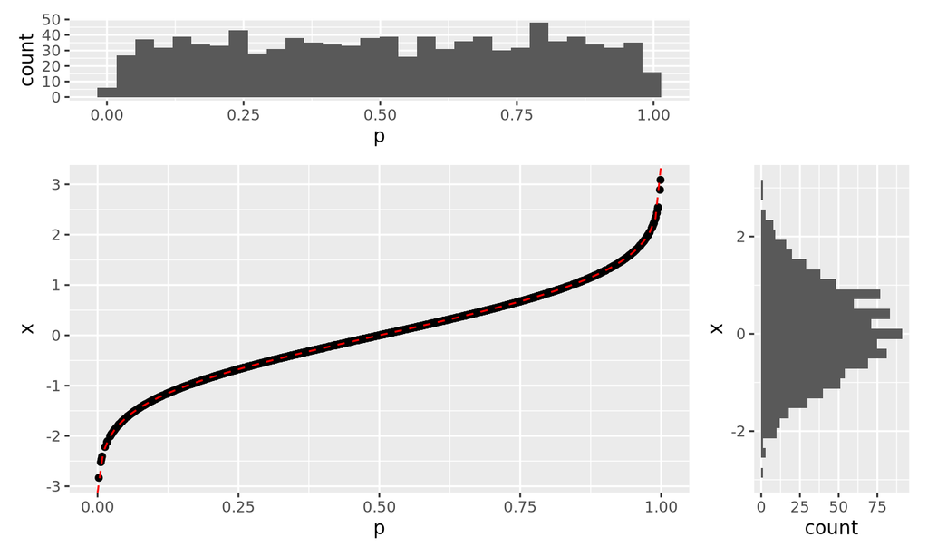

## Distributions in R

- Four key operations we perform with distributions:
1. Calculate probabilities using the PDF
2. Calculate cumulative probabilities using the CDF
3. Calculate the value associated with a cumulative probability
4. Sample values from a parameterized distribution
- Each of these operations has a dedicated function for each different distribution

## Distributions in R

- Each distribution has a family of 4 functions
- Functions end with shortened name of distribution, e.g. `norm` for normal distribution
- Distribution functions prefixed by `d`, `p`, `q`, and `r`, e.g.
1. `dnorm(x, mean=0, sd=1)` - PDF of the normal distribution
2. `pnorm(q, mean=0, sd=1)` - CDF of the normal distribution
3. `qnorm(p, mean=0, sd=1)` - inverse CDF; accepts quantiles between 0 and 1 and returns the value of the distribution for those quantiles
4. `rnorm(n, mean=0, sd=1)` - generate `n` samples from a normal distribution

## Distributions in R

| Distribution | Probability Density Function |
| --- | --- |
| Normal | `dnorm(x,mean,sd)` |
| t Distribution | `dt(x,df)` |
| Poisson | `dpois(n,lambda)` |
| Binomial | `dbinom(x, size, prob)` |
| Negative Binomial | `dnbinom(x, size, prob, mu)` |
| Exponential | `dexp(x, rate)` |
| \(\chi^2\) | `dchisq(x, df)` |

- [many more distributions available](https://www.stat.umn.edu/geyer/old/5101/rlook.html)

## Types of Distributions

## Types of Distributions

- Broadly 2 types of distributions:
  - Continuous - defined for real numbers within a range
  - Discrete - defined for all objects within a set
- A distribution may be either:
  - Theoretical (aka parametric) - defined by a parameterized family of mathematical functions
  - Empirical (aka non-parametric) - defined by data

## Discrete Distributions

- Discrete distributions defined over countable, possibly infinite sets
- Events take one of a set of discrete values
- Common discrete distributions include
  - binomial (e.g. coin flips)
  - multinomial (e.g. dice rolls)
  - Poisson (e.g. number of injuries by horse kick per day)

## Bernoulli random trails

- *Bernoulli trial* = a coin flip
- 2 outcomes with probabilities of \(p\) and \(1-p\)
- Consider a coin flip:
  - \(Pr(X = 0) = Pr(X = 1) = 0.5\) - coin is fair
  - \(Pr(X = 0) = 0.1, Pr(X = 1) = 0.9\) - coin is not fair
- Consider dice roll where we count a 6 as a success and any other roll as failure:
  - \(Pr(X = 0) = 5/6, Pr(X = 1) = 1/6\) - if dice are fair

## Bernoulli random trials

```r
library(statip) # NB: not a base R distribution
# dbern(x, prob, log = FALSE)
# qbern(p, prob, lower.tail = TRUE, log.p = FALSE)
# pbern(q, prob, lower.tail = TRUE, log.p = FALSE)
# rbern(n, prob)
rbern(10, 0.5)
```

## Bernoulli random trials

```r
rbern(10, 0.5)
```

```
##  [1] 1 1 1 0 0 1 1 1 0 1
```

## Binomial distribution

- Consider a sequence of coin flips, where chance of heads is \(p\)
- What is the probability of seeing \(x\) heads out of \(n\) flips?
- The *binomial distribution* models this situation

\[ Pr(X = x|n,p) = {n \choose x} p^x (1-p) ^{(n-x)} \]

## Binomial distribution

```r
# dbinom(x, size, prob, log = FALSE)
# pbinom(q, size, prob, lower.tail = TRUE, log.p = FALSE)
# qbinom(p, size, prob, lower.tail = TRUE, log.p = FALSE)
# rbinom(n, size, prob)
rbinom(10, 10, 0.5)
```

## Binomial distribution

```r
rbinom(10, 10, 0.5)
```

```
##  [1] 3 8 7 5 6 4 6 6 5 7
```

```r
mean(rbinom(1000, 10, 0.5))
```

```
## [1] 4.999
```

## Geometric distribution

- Consider a sequence of coin flips, where chance of heads is \(p\)
- What is the probability of seeing \(x\) consecutive tails before a head?
- The *geometric distribution* models this situation

\[ Pr(X = x|p) = (1-p)^x p \]

## Geometric distribution

```r
# dgeom(x, prob, log = FALSE)
# pgeom(q, prob, lower.tail = TRUE, log.p = FALSE)
# qgeom(p, prob, lower.tail = TRUE, log.p = FALSE)
# rgeom(n, prob)
rgeom(10, 0.5)
```

## Geometric distribution

```r
rgeom(10, 0.5)
```

```
##  [1] 2 0 3 0 2 0 2 2 0 6
```

## Poisson

- Consider an event that occurs zero or more times in a particular time period at a known constant average rate \(\lambda\)
- What is the probability of seeing \(k\) events in a time period?

\[ Pr(X=k|\lambda) = \frac {\lambda^k e^{-\lambda}} {k!} \]

## Poisson

```r
# dpois(x, lambda, log = FALSE)
# ppois(q, lambda, lower.tail = TRUE, log.p = FALSE)
# qpois(p, lambda, lower.tail = TRUE, log.p = FALSE)
# rpois(n, lambda)
rpois(10, 5)
```

## Poisson

```r
rpois(10, 5)
```

```
##  [1] 4 5 8 6 4 6 5 3 7 2
```

```r
mean(rpois(1000, 5))
```

```
## [1] 4.917
```

## Negative binomial distribution

- Consider a sequence of coin flips, where chance of heads is \(p\)
- What is the probability of seeing \(x\) tails by the time we see the \(r\) heads?

\[ Pr(X = x|r,p) = \frac {x+r-1} {r-1} p^r {(1-p)}^x \]

## Negative binomial distribution

```r
# dnbinom(x, size, prob, mu, log = FALSE)
# pnbinom(q, size, prob, mu, lower.tail = TRUE, log.p = FALSE)
# qnbinom(p, size, prob, mu, lower.tail = TRUE, log.p = FALSE)
# rnbinom(n, size, prob, mu)
rnbinom(10, 10, 0.5)
```

## Negative binomial distribution

```r
# dnbinom(x, size, prob, mu, log = FALSE)
# pnbinom(q, size, prob, mu, lower.tail = TRUE, log.p = FALSE)
# qnbinom(p, size, prob, mu, lower.tail = TRUE, log.p = FALSE)
# rnbinom(n, size, prob, mu)
rnbinom(10, 10, 0.5)
```

```
##  [1] 19  7  9 12  8  8 12 13 12 12
```

## Continuous Distributions

- Continuous distributions defined over infinite, possibly bounded domains, e.g. all real numbers

## Uniform Distribution

- Consider a number in the range \([a, b]\)
- All values in range appear with equal probability

\[ P(X=x|a,b) = \begin{cases} \frac{1}{b-a} & \text{for}\; a \le x \le b, \\ 0 & \text{otherwise} \end{cases} \]

## Uniform Distribution

```r
dunif(x, min = 0, max = 1, log = FALSE)
punif(q, min = 0, max = 1, lower.tail = TRUE, log.p = FALSE)
qunif(p, min = 0, max = 1, lower.tail = TRUE, log.p = FALSE)
runif(n, min = 0, max = 1)
runif(10, min=0, max=10)
```

## Uniform Distribution

```r
runif(10)
```

```
##  [1] 0.62197160 0.20632568 0.13773154 0.94534494 0.24755702 0.33996150
##  [7] 0.28370202 0.06990996 0.65094488 0.63905524
```

```r
mean(runif(1000))
```

```
## [1] 0.5032486
```

## Normal Distribution

- *Normal distribution (Gaussian distribution)*

\[ P(X = x|\mu,\sigma) = \frac{1}{\sigma\sqrt{2\pi}}e^{\frac{-(x-\mu)^2}{2\sigma}} \]

## Normal Distribution

```r
# dnorm(x, mean = 0, sd = 1, log = FALSE)
# pnorm(q, mean = 0, sd = 1, lower.tail = TRUE, log.p = FALSE)
# qnorm(p, mean = 0, sd = 1, lower.tail = TRUE, log.p = FALSE)
# rnorm(n, mean = 0, sd = 1)
rnorm(10, mean=10, sd=10)
```

## Normal Distribution

```r
rnorm(10, mean=10, sd=10)
```

```
##  [1] 22.264245 22.609307 13.508107  5.892955 -5.542218 18.052817 19.157577
##  [8] 20.213437  3.250644 11.789966
```

```r
mean(rnorm(1000, mean=10, sd=10))
```

```
## [1] 10.04227
```

## \(\chi^2\) Distribution

- Models the distribution of \(k\) independent standard normal random variables

\[ P(X=x|k) = \begin{cases} \frac{ x^{\frac{k}{2}-1}e^{-\frac{x}{2}} }{ 2^{\frac{k}{2}}\left ( \frac{k}{2} \right ) }, & x>0;\\ 0, & \text{otherwise} \end{cases} \]$

## \(\chi^2\) Distribution

```r
# dchisq(x, df, ncp = 0, log = FALSE)
# pchisq(q, df, ncp = 0, lower.tail = TRUE, log.p = FALSE)
# qchisq(p, df, ncp = 0, lower.tail = TRUE, log.p = FALSE)
# rchisq(n, df, ncp = 0)
rchisq(10, 10)
```

## \(\chi^2\) Distribution

```r
rchisq(10, 10)
```

```
##  [1]  7.873837 12.733304  3.567957 11.308481  5.557218 10.716813  5.477301
##  [8]  7.458366  8.126337 16.742170
```

```r
mean(rchisq(1000, 10))
```

```
## [1] 9.816199
```

## Empirical Distributions

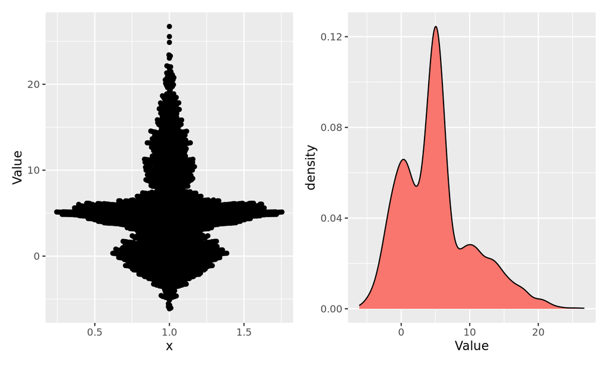

## Empirical CDF

```r
ecdf(d$Value)
```

```
## Empirical CDF
## Call: ecdf(d$Value)
##  x[1:3000] = -6.1284, -6.0381, -5.8883,  ..., 25.555, 26.728
```

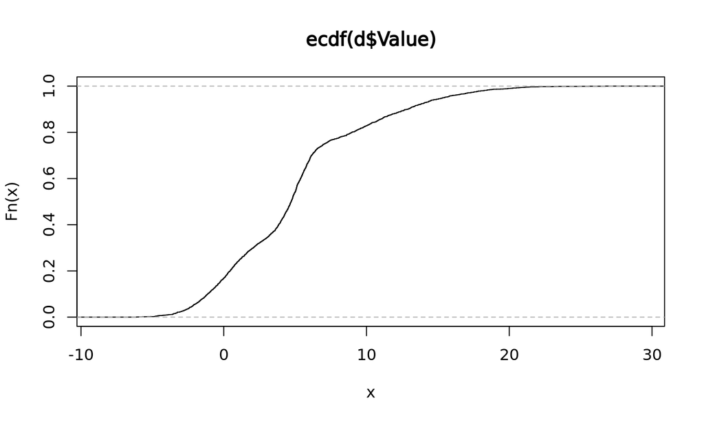

```r
plot(ecdf(d$Value))
```

## Statistical Tests

## Exploratory Data Analysis

## Exploratory Data Analysis

- We might lack sufficient information to form a scientific model
- Must first gain knowledge by examining data
- Can then possibly generate a scientific model
- This step sometimes called *exploratory data analysis* (EDA)

## Principal Component Analysis

- *principal component analysis* (PCA): statistical procedure that reduces the effective dimensionality of a dataset while preserving variance
- One of many [dimensionality reduction](https://en.wikipedia.org/wiki/Dimensionality_reduction) techniques
- Identifies so-called *directions of orthogonal variance* called *principal components*

## PCA Principles

- PCA decomposes a dataset into a set of [orthonormal basis vectors](https://en.wikipedia.org/wiki/Orthonormal_basis) (principal components)
- These principal components (PCs) collectively capture all the variance in the dataset
- First basis vector is called the *first principal component* and explains the largest fraction of the variance
- Second principal component explains the second largest fraction, and so on
- Always an equal number of principal components as there are dimensions in the dataset or the number of samples, whichever is smaller
- Typically only small number of PCs needed to explain most of the variance

## Principal Components

- Each principal component is a \(p\)-dimensional [unit vector](https://en.wikipedia.org/wiki/Unit_vector):
  - \(p\) is the number of features in the dataset
  - values are *weights* that describe the component’s direction of variance
- Product of each component with the values in each sample, we obtain a *projection*
- Projections of each sample made with each principal component produces a *rotation* of the dataset

## PCA in Biological Analysis

- Biological datasets often have many thousands of features (e.g. genes) and comparatively few samples
- Maximum number of PCs in PCA is smaller of (number of features, number of samples)
- [`stats::prcomp()`](https://www.rdocumentation.org/packages/stats/versions/3.6.2/topics/prcomp) function performs PCA in R

## PCA Example Setup

```r
# intensities contains microarray expression data for ~54k probesets x 20
# samples

# transpose expression values so samples are rows
expr_mat <- intensities %>%
  pivot_longer(-c(probeset_id),names_to="sample") %>%
  pivot_wider(names_from=probeset_id)

# PCA expects all features (i.e. probesets) to be mean-centered,
# convert to dataframe so we can use rownames
expr_mat_centered <-  as.data.frame(
  lapply(dplyr::select(expr_mat,-c(sample)),function(x) x-mean(x))
)
rownames(expr_mat_centered) <- expr_mat$sample
```

## PCA in R

```r
# prcomp performs PCA
pca <- prcomp(
  expr_mat_centered,
  center=FALSE, # already centered
  scale=TRUE # prcomp scales each feature to have unit variance
)
```

## PCA Results in R

```r
# the str() function prints the structure of its argument
str(pca)
```

```
## List of 5
##  $ sdev    : num [1:20] 101.5 81 71.2 61.9 57.9 ...
##  $ rotation: num [1:54675, 1:20] 0.00219 0.00173 -0.00313 0.00465 0.0034 ...
##   ..- attr(*, "dimnames")=List of 2
##   .. ..$ : chr [1:54675] "X1007_s_at" "X1053_at" "X117_at" "X121_at" ...
##   .. ..$ : chr [1:20] "PC1" "PC2" "PC3" "PC4" ...
##  $ center  : logi FALSE
##  $ scale   : Named num [1:54675] 0.379 0.46 0.628 0.272 0.196 ...
##   ..- attr(*, "names")= chr [1:54675] "X1007_s_at" "X1053_at" "X117_at" "X121_at" ...
##  $ x       : num [1:20, 1:20] -67.94 186.14 6.07 -70.72 9.58 ...
##   ..- attr(*, "dimnames")=List of 2
##   .. ..$ : chr [1:20] "A1" "A2" "A3" "A4" ...
##   .. ..$ : chr [1:20] "PC1" "PC2" "PC3" "PC4" ...
##  - attr(*, "class")= chr "prcomp"
```

## PCA Results in R

The result of `prcomp()` is a list with five members:

- `sdev` - the standard deviation (i.e. the square root of the variance) for each component
- `rotation` - a matrix where the principal components are in columns
- `x` - the projections of the original data
- `center` - if `center=TRUE` was passed, a vector of feature means
- `scale` - if `scale=TRUE` was passed, a vector of the feature variances

## PC Fraction of Variance

- Each principal component explains a fraction of the overall variance in the dataset
- `prcomp()` result doesn’t provide this fraction
- `sdev` variable returned by `prcomp()` may be used to first calculate the variance explained by each component by squaring it, then dividing by the sum

## PC Fraction of Variance

```r
library(patchwork)
pca_var <- tibble(
  PC=factor(str_c("PC",1:20),str_c("PC",1:20)),
  Variance=pca$sdev**2,
  `% Explained Variance`=Variance/sum(Variance)*100,
  `Cumulative % Explained Variance`=cumsum(`% Explained Variance`)
)
```

## PC Fraction of Variance Cont’d

```r
exp_g <- pca_var %>%
  ggplot(aes(x=PC,y=`% Explained Variance`,group=1)) +
  geom_point() +
  geom_line() +
  theme(axis.text.x=element_text(angle=90,hjust=0,vjust=0.5))

cum_g <- pca_var %>%
  ggplot(aes(x=PC,y=`Cumulative % Explained Variance`,group=1)) +
  geom_point() +
  geom_line() +
  ylim(0,100) + # set y limits to [0,100]
  theme(axis.text.x=element_text(angle=90,hjust=0,vjust=0.5))

exp_g | cum_g
```

## PC Fraction of Variance

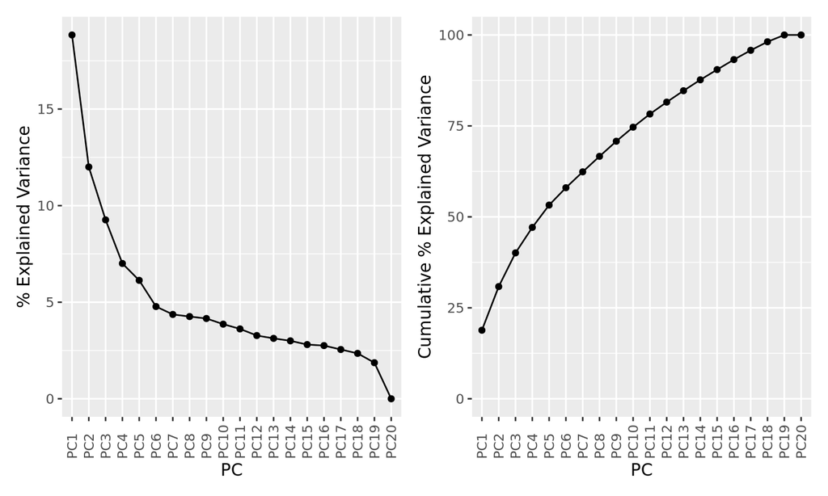

## PCA and Outliers

- PCA can help identify outlier samples
- Idea:
  - plot the projections of each sample
  - examine the result by eye to identify samples that are “far away” from the other samples
- No general rules to decide when a sample is an outlier

## Pairwise PC Plots

- PC projects often plotted against each other, e.g. PC1 vs PC2:

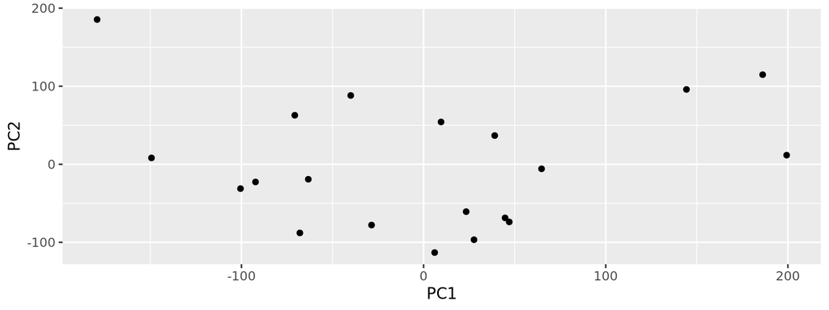

```r
as_tibble(pca$x) %>%
  ggplot(aes(x=PC1,y=PC2)) +
  geom_point()
```

## Pairwise PC Plots

- Can plot all pairs of the first six components using the [`ggpairs() function`](https://ggobi.github.io/ggally/reference/ggpairs.html) in the [GGally](https://ggobi.github.io/ggally/) package

```r
library(GGally)
as_tibble(pca$x) %>%
  dplyr::select(PC1:PC6) %>%
  ggpairs()
```

## Pairwise PC Plots

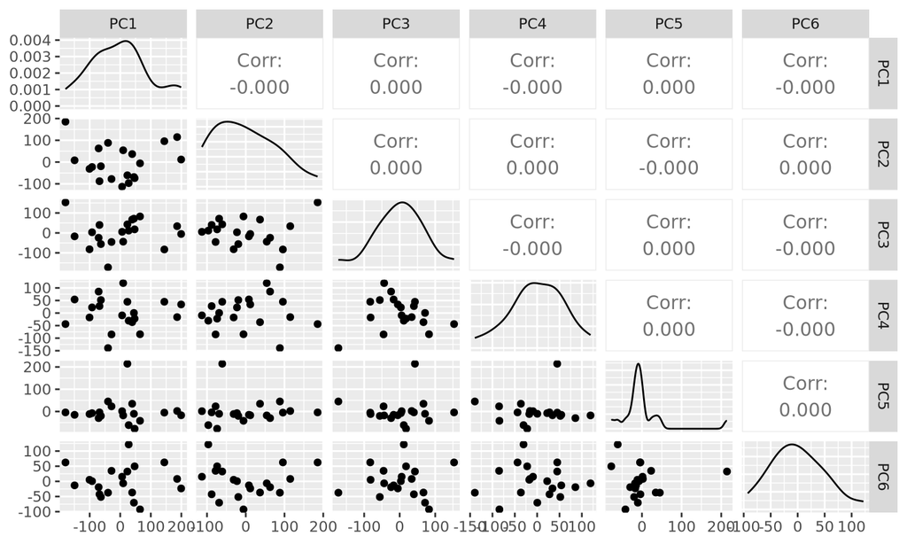

## Beeswarm PC Plots

- Alternative to scatter plots: beeswarm plot:

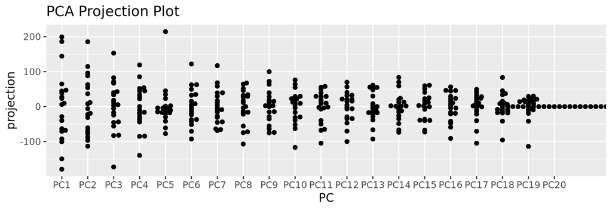

```r
as_tibble(pca$x) %>%
  pivot_longer(everything(),names_to="PC",values_to="projection") %>%
  mutate(PC=fct_relevel(PC,str_c("PC",1:20))) %>%
  ggplot(aes(x=PC,y=projection)) +
  geom_beeswarm() + labs(title="PCA Projection Plot")
```

## Adding Additional Information

- Can color our pairwise scatter plot by type like so:

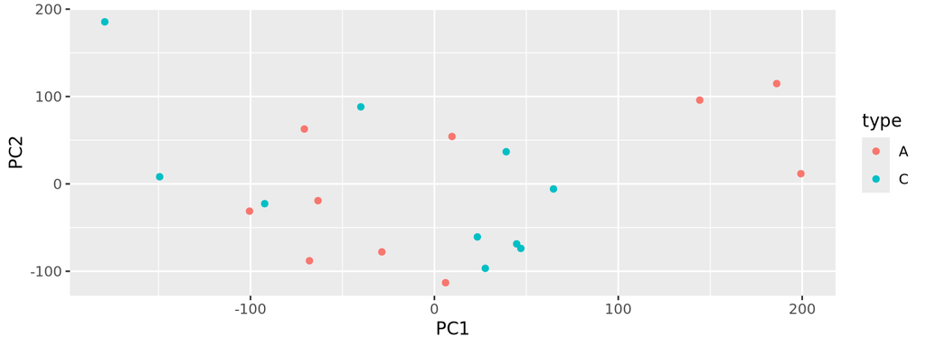

```r
as_tibble(pca$x) %>%
  mutate(type=stringr::str_sub(rownames(pca$x),1,1)) %>%
  ggplot(aes(x=PC1,y=PC2,color=type)) +
  geom_point()
```

## Adding Additional Information

- Can plot pairs of components as before but now with type information

```r
library(GGally)
as_tibble(pca$x) %>%
  mutate(type=stringr::str_sub(rownames(pca$x),1,1)) %>%
  dplyr::select(c(type,PC1:PC6)) %>%
  ggpairs(columns=1:6,mapping=aes(fill=type))
```

## Adding Additional Information

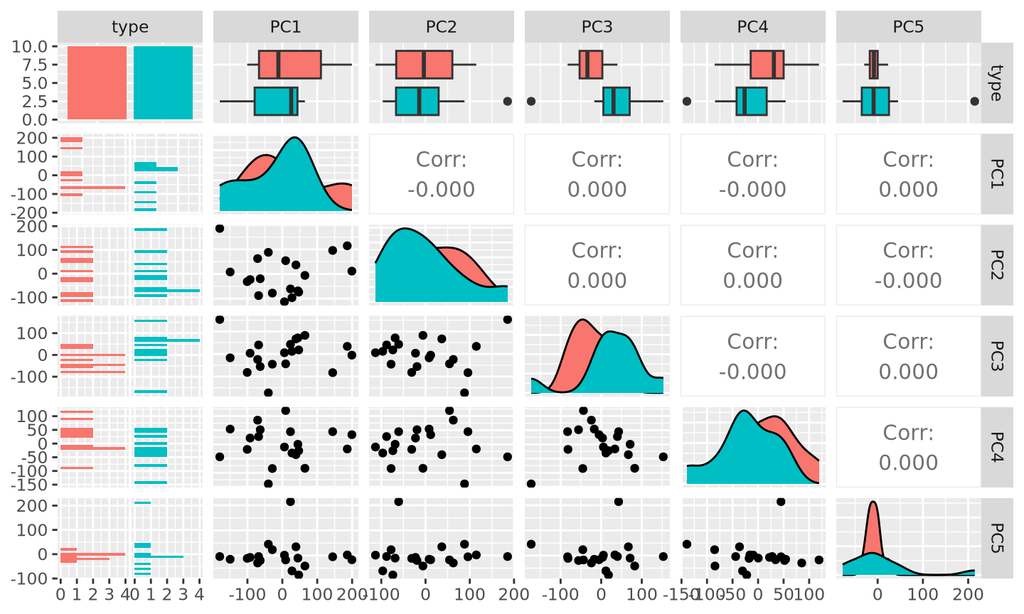

## Beeswarm PC Plots

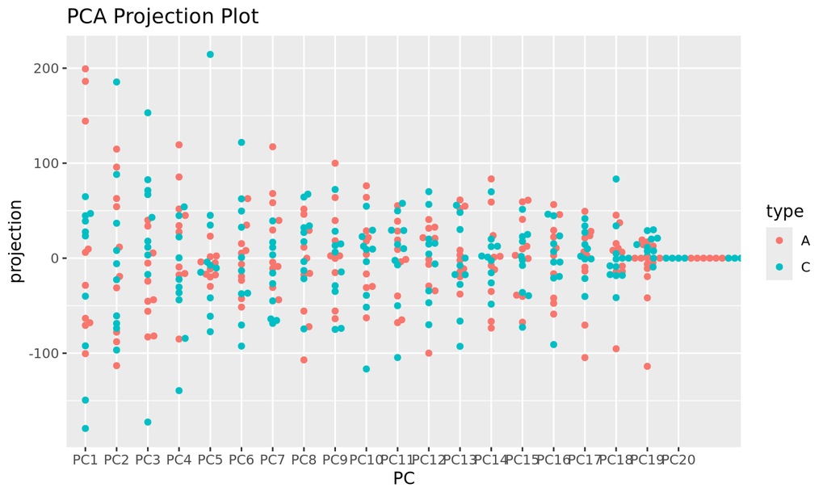

## Cluster Analysis

## Cluster Analysis

- Cluster analysis groups similar objects together
- Can identify structure or organization in a dataset
- [clustering algorithms](https://en.wikipedia.org/wiki/Category:Cluster_analysis_algorithms) have been developed for different situations

## Clustering Example

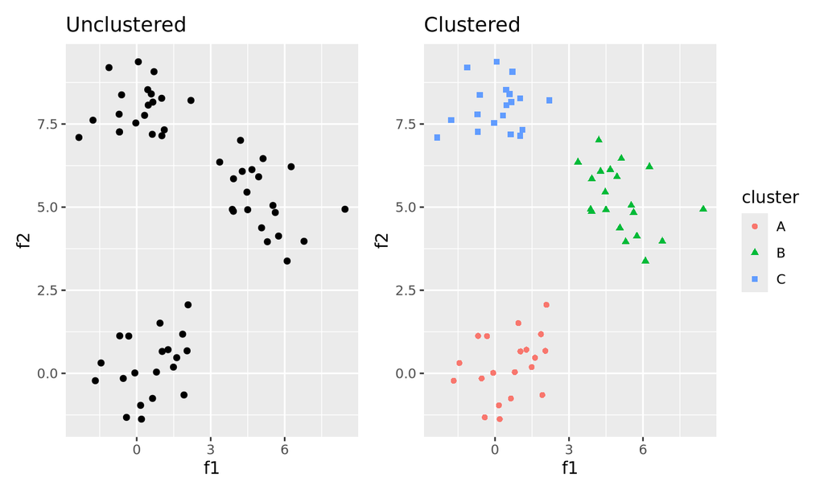

## Clustering: Distance Function

- Must choose a *distance function*, e.g \(d(x, y)\)
- \(d(x, y)\) produces a *metric* with magnitude proportional to difference between \(x\) and \(y\)
- A *metric* is a non-negative number with no meaningful unit
- Many different metrics, *euclidean distance* often a reasonable choice

\[d(p, q) = \sqrt{(p - q)^2}\]

## Clustering: Linkage Function

- In hierarchical clustering, groups of data are compared to one another
- *Linkage function* is a distance function for groups of data
- Many choices of linkage function:
  - [Single-linkage](https://en.wikipedia.org/wiki/Single-linkage_clustering) - distance between two nearest members of the groups
  - [Complete-linkage](https://en.wikipedia.org/wiki/Complete-linkage_clustering) - distance between two farthest members of the groups
  - [Unweighted Pair Group Method with Arithmetic mean (UPGMA)](https://en.wikipedia.org/wiki/UPGMA) - distance is the average distance of all pairs of points between groups
  - [Weighted Pair Group Method with Arithmetic mean (WPGMA)](https://en.wikipedia.org/wiki/WPGMA) - similar to UPGMA, but weights distances from pairs of groups evenly when merging

## Clustering Example in R

Below we will cluster the synthetic dataset introduced above in R:

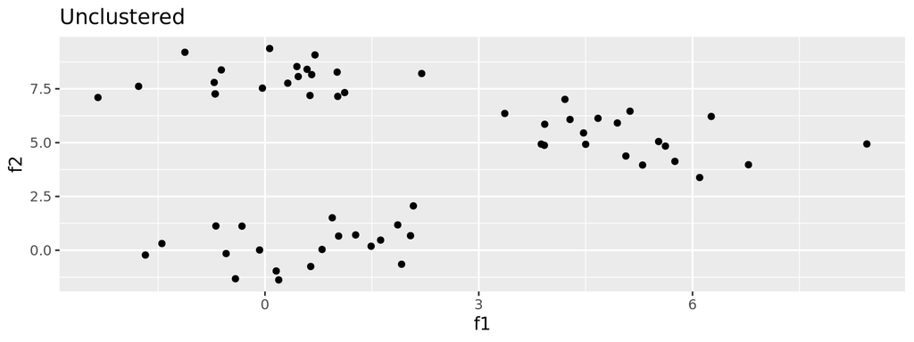

```r
ggplot(well_clustered_data, aes(x=f1,y=f2)) +
  geom_point() +
  labs(title="Unclustered")
```

## Clustering Example in R

```r
# compute all pairwise distances using euclidean distance
# as the distance metric
euc_dist <- dist(dplyr::select(well_clustered_data,-ID))

# produce a clustering of the data using the hclust for
# hierarchical clustering
hc <- hclust(euc_dist, method="ave")

# add ID as labels to the clustering object
hc$labels <- well_clustered_data$ID
```

## Clustering Example in R

```r
str(hc)
```

```
## List of 7
##  $ merge      : int [1:59, 1:2] -50 -33 -48 -46 -44 -21 -11 -4 -36 -3 ...
##  $ height     : num [1:59] 0.00429 0.08695 0.23536 0.24789 0.25588 ...
##  $ order      : int [1:60] 8 9 7 6 19 18 11 16 4 14 ...
##  $ labels     : chr [1:60] "A1" "A2" "A3" "A4" ...
##  $ method     : chr "average"
##  $ call       : language hclust(d = euc_dist, method = "ave")
##  $ dist.method: chr "euclidean"
##  - attr(*, "class")= chr "hclust"
```

## `hclust()` output

- `hclust()` return object describes the clustering as a tree
- Can visualize using a dendrogram:

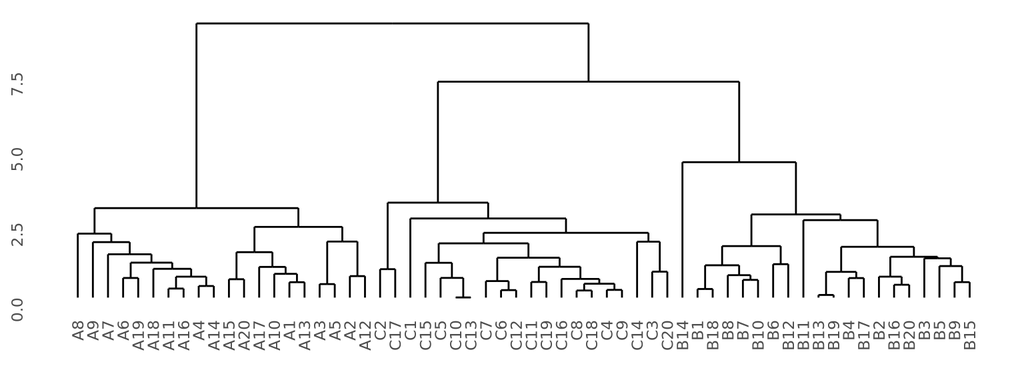

```r
library(ggdendro)
ggdendrogram(hc)
```

## Creating Flat Clusters

- Can split hierarchical clustering into groups based on their pattern
- Can use the [`cutree`](https://www.rdocumentation.org/packages/stats/versions/3.6.2/topics/cutree) to divide the tree into three groups using `k=3`:

```r
labels <- cutree(hc,k=3)
labels
```

```
##  A1  A2  A3  A4  A5  A6  A7  A8  A9 A10 A11 A12 A13 A14 A15 A16 A17 A18 A19 A20
##   1   1   1   1   1   1   1   1   1   1   1   1   1   1   1   1   1   1   1   1
##  B1  B2  B3  B4  B5  B6  B7  B8  B9 B10 B11 B12 B13 B14 B15 B16 B17 B18 B19 B20
##   2   2   2   2   2   2   2   2   2   2   2   2   2   2   2   2   2   2   2   2
##  C1  C2  C3  C4  C5  C6  C7  C8  C9 C10 C11 C12 C13 C14 C15 C16 C17 C18 C19 C20
##   3   3   3   3   3   3   3   3   3   3   3   3   3   3   3   3   3   3   3   3
```

## Creating Flat Clusters

```r
# we turn our labels into a tibble so we can join them with the original tibble
well_clustered_data %>%
  left_join(
    tibble(
      ID=names(labels),
      label=as.factor(labels)
    )
  ) %>%
  ggplot(aes(x=f1,y=f2,color=label)) +
  geom_point() +
  labs(title="Clustered")
```

## Creating Flat Clusters

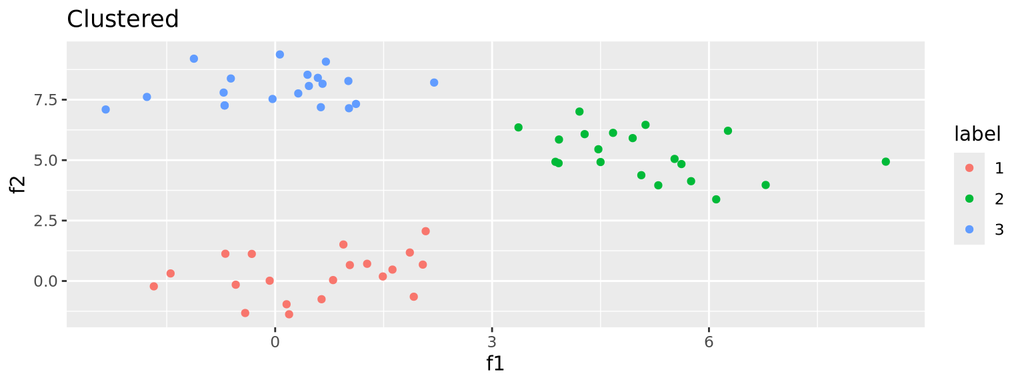

```r
# we turn our labels into a tibble so we can join them with the original tibble
well_clustered_data %>%
  left_join(
    tibble(
      ID=names(labels),
      label=as.factor(labels)
    )
  ) %>%
  ggplot(aes(x=f1,y=f2,color=label)) +
  geom_point() +
  labs(title="Clustered")
```